# Huisman_Weissing_2001_report

Frank Pennekamp

10/28/2016

Here I aim to reproduce the paper “Fundamental unpredictability in multispecies competition” by [Huisman & Weissing (2001)](http://www.jstor.org/stable/10.1086/319929?seq=1#page_scan_tab_contents).

> Abstract: One of the central goals of ecology is to predict the distribution and abundance of organisms. Here, we show that, in ecosystems of high biodiversity, the outcome of multispecies competition can be fundamentally unpredictable. We consider a competition model widely applied in phytoplankton ecology and plant ecology in which multiple species compete for three resources. We show that this competition model may have several alternative outcomes, that the dynamics leading to these alternative outcomes may exhibit transient chaos, and that the basins of attraction of these alternative outcomes may have an intermingled fractal geometry. As a consequence of this fractal geometry, it is impossible to predict the winners of multispecies competition in advance.

Two models based on the same principles are used in the paper: a 5 species model with competition over three limiting resources, and an 8 species competition model (where three additional species invade the 5 species community).

## Figure 1

(uses a 8 species community, will be added later)

## Figure 2 a)

Then simulate dynamics of 5 species with equal starting conditions (0.1) for all competitors and resources (10).

```r
# define parameters for model simulation
parms <- c(r=1)

# set up starting conditions
initial_cond1 <- c(0.1, 0.1, 0.1, 0.1, 0.1, 10, 10, 10)

# simulate dynamics for 2000 time steps (days) using Runge-Kutta algorithm and time step of 0.01 days
out1 <- ode(y = initial_cond1 , times = 1:2000, func = r_star_5, parms = parms)
```

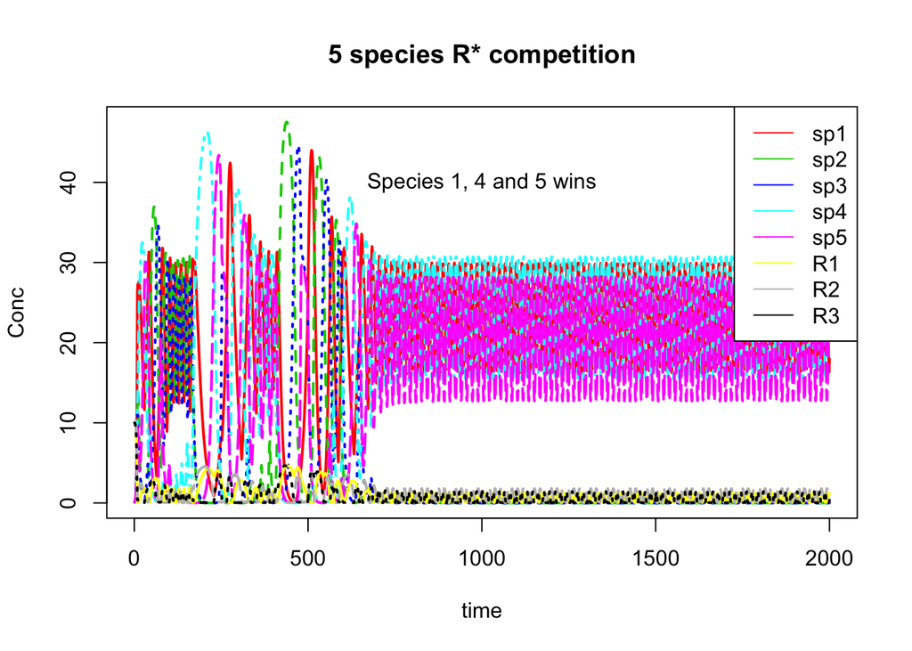

```r
matplot(out1[1:2000 , 2:9], type = "l", xlab = "time", ylab = "Conc",
        main = "5 species R* competition", lwd = 2, col=2:9)
legend("topright", c("sp1", "sp2", "sp3", "sp4","sp5", "R1", "R2", "R3"), col = 2:9, lty = 1)
text(x=1000, y = 40, labels = "Species 1, 4 and 5 wins")
```

## Figure 2 b)

Now simulate dynamics of 5 species with equal starting conditions (0.1) except N_2 (0.2) .

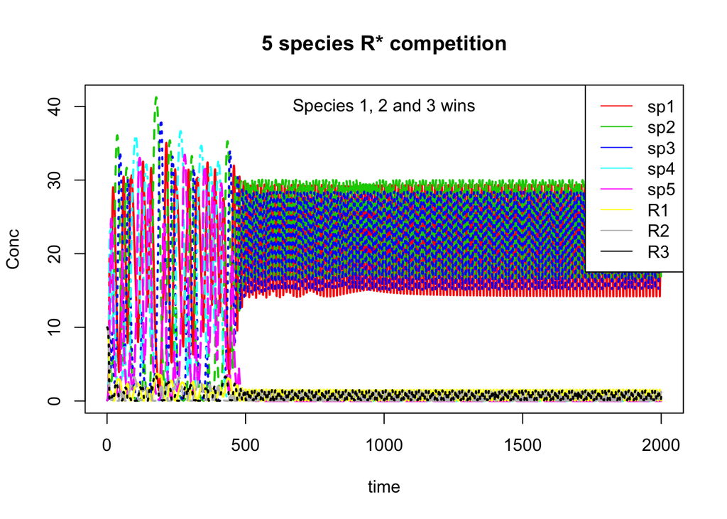

[figure not shown]

```r
matplot(out2[1:2000 , 2:9], type = "l", xlab = "time", ylab = "Conc",
        main = "5 species R* competition", lwd = 2, col=2:9)
legend("topright", c("sp1", "sp2", "sp3", "sp4","sp5", "R1", "R2", "R3"), col = 2:9, lty = 1)
text(x=1000, y = 40, labels = "Species 1, 2 and 3 wins")
```

Check the outcome of competition based on different starting values:

```r
## old, not parallel function

# set up initial conditions to vary across species 2 & 4
initial_condition <- expand.grid(sp2=seq(0.00001,2,length.out = 40), sp4=seq(0,2,length.out = 40))
initial_condition$sp1 <- initial_condition$sp3 <- initial_condition$sp5 <- 0.1
initial_condition$R1 <- initial_condition$R2 <- initial_condition$R3 <- 10

# re-arrange according to species identity
initial_condition <- initial_condition[, c(5,1,4,2,3,6,7,8) ]

tic <- Sys.time()
basins <- lapply(1:1, function(x) ode(y = as.numeric(initial_condition[x, ]), times = 1:2000, func = r_star_5))
toc <- Sys.time()
toc-tic

save(basins, file = "/Users/frank/Documents/Git projects/RREEBES/Huisman_Weissing_2001/basins2.RData")

# check one output
# matplot(basins[[92]][1:2000 , 2:9], type = "l", xlab = "time", ylab = "Conc",
#         main = "5 species R* competition", lwd = 2, col=2:9)
# legend("topright", c("sp1", "sp2", "sp3", "sp4","sp5", "R1", "R2", "R3"), col = 2:9, lty = 1)
```

Set up initial conditions:

```r
time_steps <- 2000
resolution <- 100

# set up initial conditions to vary across species 2 & 4
initial_condition <- expand.grid(sp2=seq(0.00001,2,length.out = resolution), sp4=seq(0,2,length.out = resolution))
initial_condition$sp1 <- initial_condition$sp3 <- initial_condition$sp5 <- 0.1
initial_condition$R1 <- initial_condition$R2 <- initial_condition$R3 <- 10

# re-arrange according to species identity
initial_condition <- initial_condition[, c(5,1,4,2,3,6,7,8)]
```

Simulate:

```r
library(parallel)


# Calculate the number of cores
no_cores <- detectCores() - 2

# Initiate cluster
cl <- makeCluster(no_cores, type="FORK")

r_star_5_par <- function(x, time_steps, resolution){

# set up initial conditions to vary across species 2 & 4
initial_condition <- expand.grid(sp2=seq(0.00001,2,length.out = resolution), sp4=seq(0,2,length.out = resolution))
initial_condition$sp1 <- initial_condition$sp3 <- initial_condition$sp5 <- 0.1
initial_condition$R1 <- initial_condition$R2 <- initial_condition$R3 <- 10

# re-arrange according to species identity
initial_condition <- initial_condition[, c(5,1,4,2,3,6,7,8) ]

init <- as.numeric(initial_condition[x, ])

list(ode(y = init, times = 1:time_steps, func = r_star_5))

}

clusterExport(cl, list("r_star_5_par", "time_steps", "resolution"))

#basins <- lapply(1:nrow(initial_condition), function(x) ode(y = as.numeric(initial_condition[x, ]), times = 1:time_steps, func = r_star_5))
basins2 <- parLapply(cl, 1:nrow(initial_condition), function(x) {r_star_5_par(x, time_steps, resolution)})
#save(basins2, file = "/Users/frankpennekamp/Github/RREEBES/Huisman_Weissing_2001/basins2.RData")

stopCluster(cl)
```

```r
load(file = "/Users/frankpennekamp/Github/RREEBES/Huisman_Weissing_2001/basins2.RData")

# evaluate which species persist
comp_out <- function(x, time, biomass_threshold){
  x <- as.data.frame(x)
  log <- x[time,2:6] > biomass_threshold
  winners <- c("sp1", "sp2", "sp3", "sp4", "sp5")[log]
  winners <- stringr::str_c(winners, collapse = ", ")
  paste0( "winners: ", winners)

  }

result <- lapply(basins2, comp_out, time = time_steps, biomass_threshold = 5)
initial_condition$res <- unlist(result)
```

## Figure 3

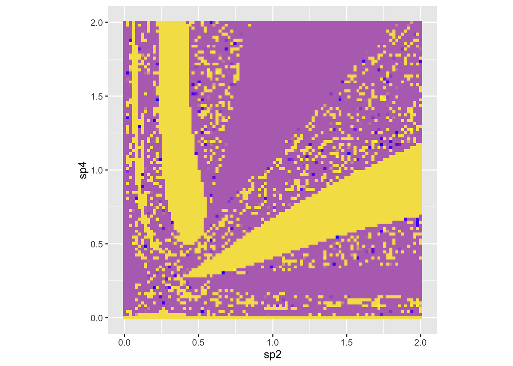

```r
#image(matrix(ifelse(initial_condition$res == "winners: sp1, sp2, sp3", 1,0), byrow = F, ncol = 40),col=c("blue", "yellow"))

library(ggplot2)
ggplot(initial_condition, aes(x=sp2, y=sp4, fill=as.numeric(as.factor(initial_condition$res)))) + geom_tile() + scale_fill_gradient(low = "yellow", high = "blue") + guides(fill=F) + coord_fixed()
```